# Assignment modue no 7 In python

CAR Data Cleaning and practicing

Description of dataset:- sourcing information is silent , dont know whrere is data came form, we hopind a imaginary car dataset,as It is a Car dataset we are more intrested into looking into MPG:- milage per gallon of dataset for gaining more and more inforamation out of it.

```python
import pandas as pd
```

```python
df = pd.read_csv('Cars.csv') #  attribut4e
```

```python
df.head()
```

|  | HP | MPG | VOL | SP | WT |
| --- | --- | --- | --- | --- | --- |
| 0 | 49 | 53.700681 | 89 | 104.185353 | 28.762059 |
| 1 | 55 | 50.013401 | 92 | 105.461264 | 30.466833 |
| 2 | 55 | 50.013401 | 92 | 105.461264 | 30.193597 |
| 3 | 70 | 45.696322 | 92 | 113.461264 | 30.632114 |
| 4 | 53 | 50.504232 | 92 | 104.461264 | 29.889149 |

What is menaing of meaning of data that shoud be understood first HP - Engine Horse power , MPG- Milage per galloon(Average miles per gallon) , VOL -Cubic feet of cab space , SP- Speed per hour , Wt - Weight of the vehicle

But those data does not represent the vehicle items or car names From which the data came from , I am just taking each observation of index no 1 to 81 as like Numbers of Cars in this dataset.

```python
df.describe()# by using this we can able to see the overview of particular data types
```

|  | HP | MPG | VOL | SP | WT |
| --- | --- | --- | --- | --- | --- |
| count | 81.000000 | 81.000000 | 81.000000 | 81.000000 | 81.000000 |
| mean | 117.469136 | 34.422076 | 98.765432 | 121.540272 | 32.412577 |
| std | 57.113502 | 9.131445 | 22.301497 | 14.181432 | 7.492813 |
| min | 49.000000 | 12.101263 | 50.000000 | 99.564907 | 15.712859 |
| 25% | 84.000000 | 27.856252 | 89.000000 | 113.829145 | 29.591768 |
| 50% | 100.000000 | 35.152727 | 101.000000 | 118.208698 | 32.734518 |
| 75% | 140.000000 | 39.531633 | 113.000000 | 126.404312 | 37.392524 |
| max | 322.000000 | 53.700681 | 160.000000 | 169.598513 | 52.997752 |

### Playing with attributes

```python
df.var() # values varies form the mean by
```

```
HP     3261.952160
MPG      83.383283
VOL     497.356790
SP      201.113002
WT       56.142247
dtype: float64
```

```python
df.info() # our structure of data
```

```
<class 'pandas.core.frame.DataFrame'>
RangeIndex: 81 entries, 0 to 80
Data columns (total 5 columns):
 #   Column  Non-Null Count  Dtype
---  ------  --------------  -----
 0   HP      81 non-null     int64
 1   MPG     81 non-null     float64
 2   VOL     81 non-null     int64
 3   SP      81 non-null     float64
 4   WT      81 non-null     float64
dtypes: float64(3), int64(2)
memory usage: 3.3 KB
```

```python
print(df)
```

```
     HP        MPG  VOL          SP         WT
0    49  53.700681   89  104.185353  28.762059
1    55  50.013401   92  105.461264  30.466833
2    55  50.013401   92  105.461264  30.193597
3    70  45.696322   92  113.461264  30.632114
4    53  50.504232   92  104.461264  29.889149
..  ...        ...  ...         ...        ...
76  322  36.900000   50  169.598513  16.132947
77  238  19.197888  115  150.576579  37.923113
78  263  34.000000   50  151.598513  15.769625
79  295  19.833733  119  167.944460  39.423099
80  236  12.101263  107  139.840817  34.948615

[81 rows x 5 columns]
```

```python
df.isnull() # there is no null value
```

|  | HP | MPG | VOL | SP | WT |
| --- | --- | --- | --- | --- | --- |
| 0 | False | False | False | False | False |
| 1 | False | False | False | False | False |
| 2 | False | False | False | False | False |
| 3 | False | False | False | False | False |
| 4 | False | False | False | False | False |
| ... | ... | ... | ... | ... | ... |
| 76 | False | False | False | False | False |
| 77 | False | False | False | False | False |
| 78 | False | False | False | False | False |
| 79 | False | False | False | False | False |
| 80 | False | False | False | False | False |

81 rows × 5 columns

```python
df.isna().sum() # no na value as we can see no missing value present in our data
```

```
HP     0
MPG    0
VOL    0
SP     0
WT     0
dtype: int64
```

some how i will findout intrepareation of different data in order to understand its feature i need to see its different corleantio point of each data types and correlaiion of each coulumns lets get numeric value of each column

```python
df.corr() # finding the cor relation of each point to extract the features of the data
```

|  | HP | MPG | VOL | SP | WT |
| --- | --- | --- | --- | --- | --- |
| HP | 1.000000 | -0.725038 | 0.077459 | 0.973848 | 0.076513 |
| MPG | -0.725038 | 1.000000 | -0.529057 | -0.687125 | -0.526759 |
| VOL | 0.077459 | -0.529057 | 1.000000 | 0.102170 | 0.999203 |
| SP | 0.973848 | -0.687125 | 0.102170 | 1.000000 | 0.102439 |
| WT | 0.076513 | -0.526759 | 0.999203 | 0.102439 | 1.000000 |

```python
import seaborn as sns
```

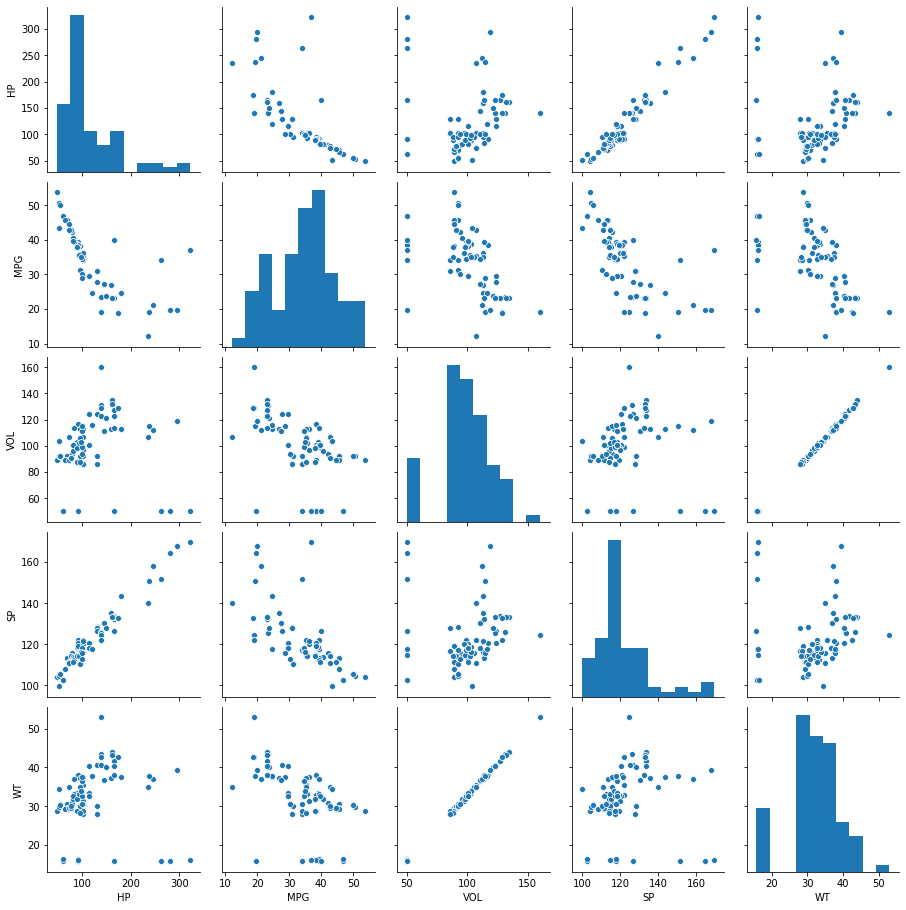

```python
sns.pairplot(df) # we suppose to check correaltion of each variavle with different variable in data set
```

```python
import matplotlib.pyplot as plt
```

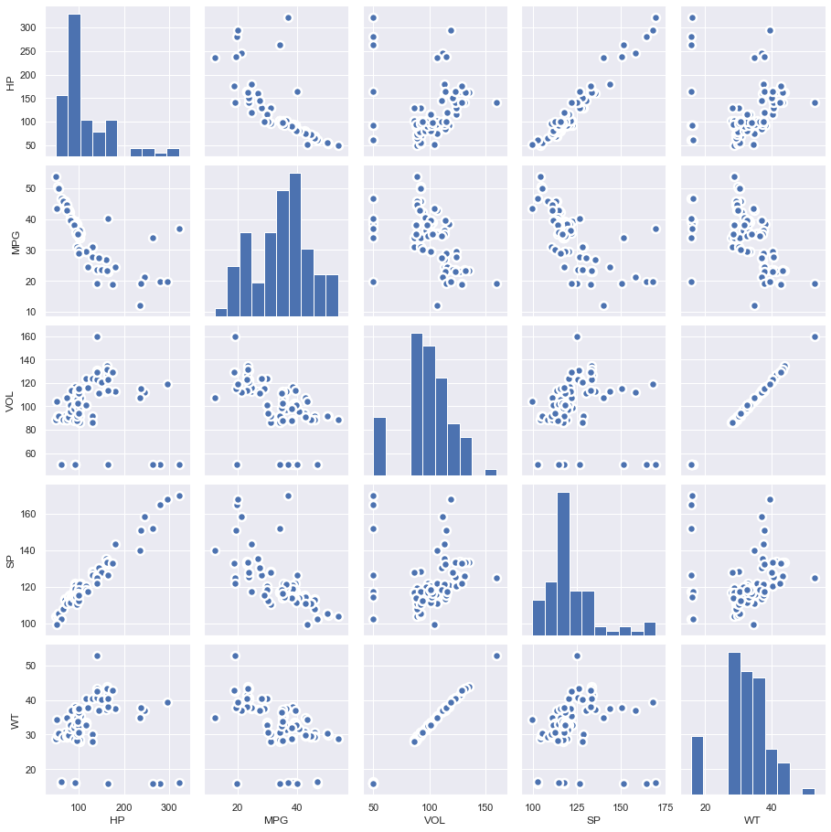

```python
plt.figure(figsize=(10,8), dpi= 80)
sns.pairplot(df, kind="scatter", plot_kws=dict(s=80, edgecolor="white", linewidth=2.5))
plt.show()
```

lsets see distribution of variable of in a boxplot

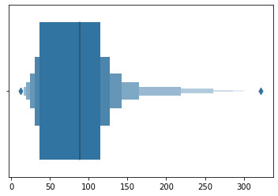

```python
sns.boxenplot(df) # it shows how data is spread across the box plot
```

the information or the distrubution of data can be seen from 40 to 120 of data demarketed above

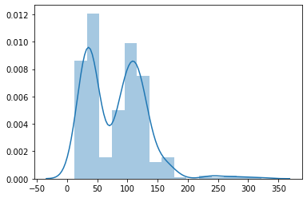

```python
sns.distplot(df) # it shows the distribution of the data
```

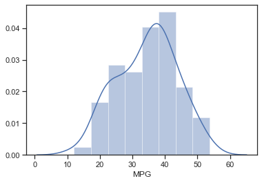

```python
sns.distplot(df['MPG'])  # we can see the distribution of the mpg
```

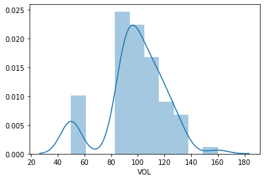

```python
sns.distplot(df['VOL'])
```

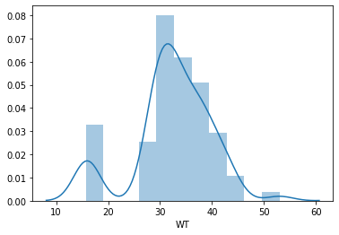

```python
sns.distplot(df['WT'])
```

From the above distribution we can see that how it is matching with each other as if thery are same volumen and weight

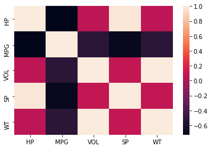

```python
sns.heatmap(df.corr())
```

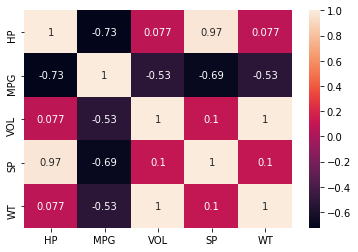

```python
sns.heatmap(df.corr(),annot=True) # checking correlation of each number
```

From the above hp is corelated it can be seen that hp has co realtion with manry variable above and MPG is negatively correlated and vol ,sp ,weight some how negatively correalted , and sp shows high digreee of positive correaltion

```python
df.columns # viewing the columns indicating our data frame
```

```
Index(['HP', 'MPG', 'VOL', 'SP', 'WT'], dtype='object')
```

```python
X = df[['HP', 'VOL', 'SP', 'WT']] # my feature variable
```

```python
Y = df[['MPG']] # my target variabe
```

```python
import scipy.stats as stats # import scipy model and pylab for qqline and qqplot in python
import pylab
```

Lets Check each Variable normality

[output not shown]

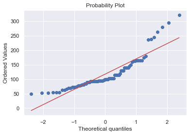

```python
stats.probplot(df.HP,dist ="norm",plot =pylab)
```

HP it is not normally distributes clearly visible as we can see the data points

[output not shown]

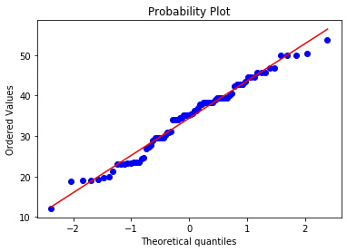

```python
stats.probplot(df.MPG,dist ="norm",plot = pylab)
```

AS we can see the probablity point of this data is normally distributed

[output not shown]

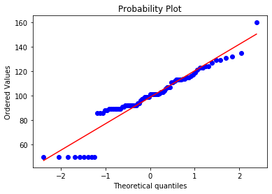

```python
stats.probplot(df.VOL, dist = "norm", plot = pylab)
```

we can see the distribution of the points on the line as it seems not normal

[output not shown]

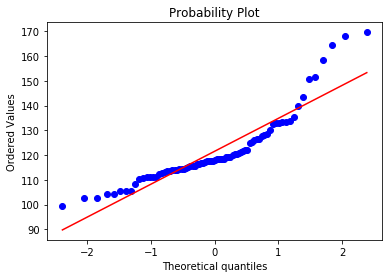

```python
stats.probplot(df.SP, dist = "norm",plot = pylab)
```

as we can see the points it seems normal but not a normal

[output not shown]

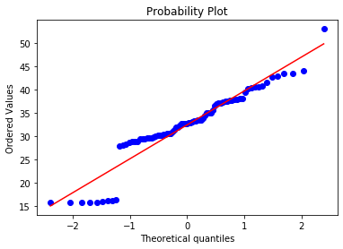

```python
stats.probplot(df.WT,dist ="norm",plot =pylab)
```

it is also not a normal as looks like

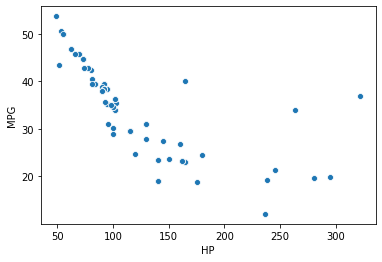

```python
sns.scatterplot(x='HP',y='MPG',data=df) # lets do some scatterplot
```

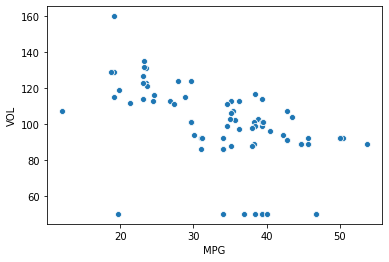

```python
sns.scatterplot(x='MPG',y='VOL',data=df)
```

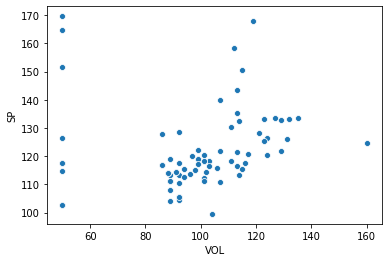

```python
sns.scatterplot(x='VOL',y='SP',data=df)
```

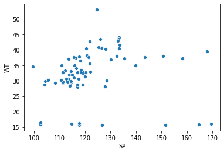

```python
sns.scatterplot(x='SP',y='WT',data=df)
```

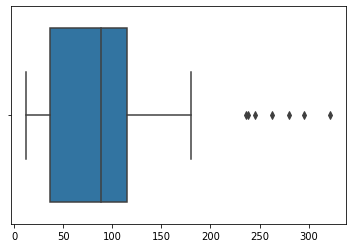

```python
sns.boxplot(df) # box plot suggesting outliers but we will find each data outliers lets see seach
```

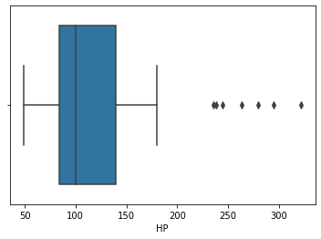

```python
sns.boxplot(df['HP']) # Hp already seend multiple outlers
```

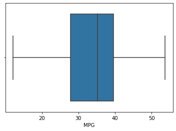

```python
sns.boxplot(df['MPG']) # no outliers seems
```

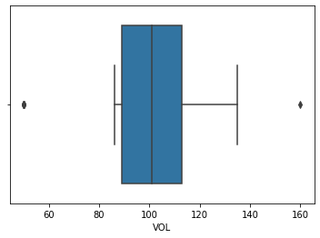

```python
sns.boxplot(df['VOL']) # two outliers point in respective side
```

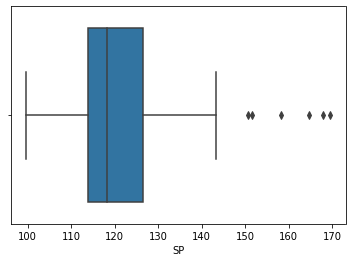

```python
sns.boxplot(df['SP'])  # outliers
```

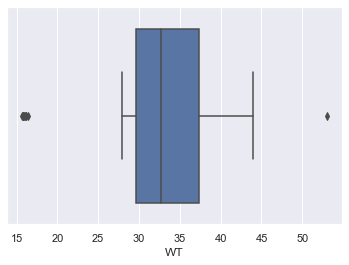

```python
sns.boxplot(df['WT']) # outliers
```

```python
import seaborn as sns; sns.set()
```

```python
import matplotlib.pyplot as plt
```

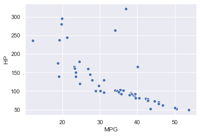

```python
ax = sns.scatterplot(x="MPG", y="HP", data=df)
```

# Creating Statistical models

```python
import statsmodels.formula.api as smf
```

```python
model = smf.ols('MPG~WT+VOL+SP+HP',data=df).fit()
```

```python
model.conf_int # stats model coffient
```

```
<bound method RegressionResults.conf_int of <statsmodels.regression.linear_model.RegressionResultsWrapper object at 0x000001EC86905C88>>
```

```python
print(model.summary()) # summary of the model
```

```
                            OLS Regression Results
==============================================================================
Dep. Variable:                    MPG   R-squared:                       0.771
Model:                            OLS   Adj. R-squared:                  0.758
Method:                 Least Squares   F-statistic:                     63.80
Date:                Sun, 19 Jul 2020   Prob (F-statistic):           1.54e-23
Time:                        19:10:08   Log-Likelihood:                -233.96
No. Observations:                  81   AIC:                             477.9
Df Residuals:                      76   BIC:                             489.9
Df Model:                           4
Covariance Type:            nonrobust
==============================================================================
                 coef    std err          t      P>|t|      [0.025      0.975]
------------------------------------------------------------------------------
Intercept     30.6773     14.900      2.059      0.043       1.001      60.354
WT             0.4006      1.693      0.237      0.814      -2.972       3.773
VOL           -0.3361      0.569     -0.591      0.556      -1.469       0.796
SP             0.3956      0.158      2.500      0.015       0.080       0.711
HP            -0.2054      0.039     -5.239      0.000      -0.284      -0.127
==============================================================================
Omnibus:                       10.780   Durbin-Watson:                   1.403
Prob(Omnibus):                  0.005   Jarque-Bera (JB):               11.722
Skew:                           0.707   Prob(JB):                      0.00285
Kurtosis:                       4.215   Cond. No.                     6.09e+03
==============================================================================

Warnings:
[1] Standard Errors assume that the covariance matrix of the errors is correctly specified.
[2] The condition number is large, 6.09e+03. This might indicate that there are
strong multicollinearity or other numerical problems.
```

```python
model.summary2 # short status summary of our model
```

```
<bound method RegressionResults.summary2 of <statsmodels.regression.linear_model.OLSResults object at 0x000001EC8691F988>>
```

```python
model.fittedvalues # fitted values
```

```
0     43.441935
1     42.388793
2     42.279341
3     42.538360
4     42.172648
        ...
76    21.282096
77    17.899050
78    26.136453
79    12.316612
80    15.559481
Length: 81, dtype: float64
```

```python
%matplotlib inline
```

```python
from statsmodels.compat import lzip
import numpy as np
import matplotlib.pyplot as plt
import statsmodels.api as sm
from statsmodels.formula.api import ols
```

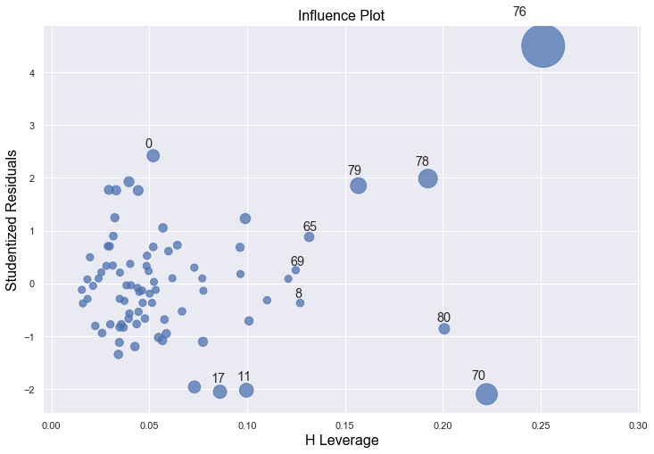

```python
fig, ax = plt.subplots(figsize=(12,8))
fig = sm.graphics.influence_plot(model, ax=ax, criterion="cooks")
```

```python
influence = model.get_influence()
```

```python
from statsmodels.graphics.regressionplots import *
```

[output not shown]

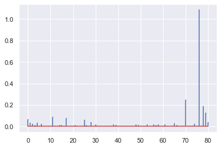

```python
(c, p) = influence.cooks_distance
plt.stem(np.arange(len(c)), c, markerfmt=",")
```

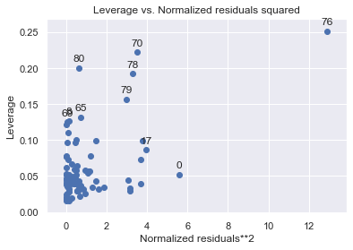

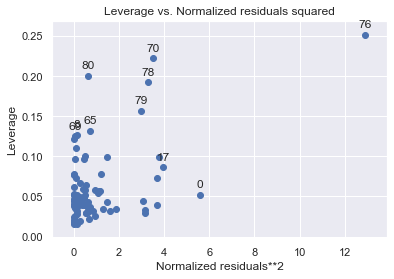

```python
plot_leverage_resid2(model)
```

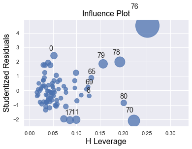

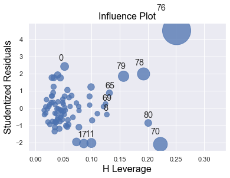

```python
influence_plot(model)
```

```python
from scipy import stats
import numpy as np
z = np.abs(stats.zscore(df))
```

```python
threshold = 4
print(np.where(z > 3)) # we dignosed our outliers
```

```
(array([70, 76, 76, 79, 79], dtype=int64), array([3, 0, 3, 0, 3], dtype=int64))
```

```python
print(z[70]) # through this we can find out the pointing variation
```

```
[2.86348272 1.62465312 2.20026792 3.05515833 2.22785207]
```

```python
print(z[76])# for 76 also
```

```
[3.60344233 0.27305243 2.20026792 3.40992879 2.18623649]
```

```python
print(z[79])# for 79 also
```

```
[3.12775401 1.60754809 0.91297193 3.292567   0.94146241]
```

```python
print(z[70][1])
```

```
1.624653122908629
```

```python
print(z[76][1])
```

```
0.27305243311314065
```

```python
print(z[79][1])
```

```
1.6075480888892086
```

But we are chooseing 76 as outlier outside variable as it is seen

```python
model1 = smf.ols('MPG~WT+VOL+SP+HP',data=df).fit()
```

```python
df.info()
```

```
<class 'pandas.core.frame.DataFrame'>
RangeIndex: 81 entries, 0 to 80
Data columns (total 5 columns):
 #   Column  Non-Null Count  Dtype
---  ------  --------------  -----
 0   HP      81 non-null     int64
 1   MPG     81 non-null     float64
 2   VOL     81 non-null     int64
 3   SP      81 non-null     float64
 4   WT      81 non-null     float64
dtypes: float64(3), int64(2)
memory usage: 3.3 KB
```

```python
df.dtypes
```

```
HP       int64
MPG    float64
VOL      int64
SP     float64
WT     float64
dtype: object
```

```python
import numpy as np
```

df.drop([df.index[76]]) # i dropped the value index 76 as it is the outlier

```python
model2 = smf.ols('MPG~WT+VOL+SP+HP',data=df.drop([df.index[76]])).fit() # dropped the 76 item in our
```

```python
print(model2.summary()) # after removing the out
```

```
                            OLS Regression Results
==============================================================================
Dep. Variable:                    MPG   R-squared:                       0.819
Model:                            OLS   Adj. R-squared:                  0.810
Method:                 Least Squares   F-statistic:                     84.96
Date:                Sun, 19 Jul 2020   Prob (F-statistic):           4.42e-27
Time:                        19:10:40   Log-Likelihood:                -222.00
No. Observations:                  80   AIC:                             454.0
Df Residuals:                      75   BIC:                             465.9
Df Model:                           4
Covariance Type:            nonrobust
==============================================================================
                 coef    std err          t      P>|t|      [0.025      0.975]
------------------------------------------------------------------------------
Intercept     27.8268     13.323      2.089      0.040       1.287      54.367
WT             0.0375      1.515      0.025      0.980      -2.980       3.055
VOL           -0.1855      0.509     -0.364      0.717      -1.199       0.828
SP             0.4119      0.141      2.913      0.005       0.130       0.694
HP            -0.2266      0.035     -6.413      0.000      -0.297      -0.156
==============================================================================
Omnibus:                        9.877   Durbin-Watson:                   1.127
Prob(Omnibus):                  0.007   Jarque-Bera (JB):                9.708
Skew:                           0.768   Prob(JB):                      0.00780
Kurtosis:                       3.744   Cond. No.                     5.99e+03
==============================================================================

Warnings:
[1] Standard Errors assume that the covariance matrix of the errors is correctly specified.
[2] The condition number is large, 5.99e+03. This might indicate that there are
strong multicollinearity or other numerical problems.
```

```python
df.columns # viewing the columns indicating our data frame
```

```
Index(['HP', 'MPG', 'VOL', 'SP', 'WT'], dtype='object')
```

```python
X = df[['HP', 'VOL', 'SP', 'WT']] # my feature variable
```

```python
y = df[['MPG']] # my y variable  same can be do as well as you like
```